# Kõik teev viivad Paenastisse*

Tegin selle postituse inspireerituna erinevatest visuaalidest, mis kujutavad seda kuidas kõik teed viivad Rooma (või mõnda muusse linna), [This Map Shows That All Roads Basically Do Lead to Rome](https://www.citylab.com/design/2015/12/this-map-shows-that-all-roads-basically-do-lead-to-rome/420093/). Otsustasin sarnase pildi teha Eesti geograafilise keskpunkti, **Paenasti**, kohta.

Kaardi joonsitamiseks leidsin kõik Eesti linnad, vallad, alevid, alavikud, linnaosad ja random 1000 küla. Seejärel arvutasin Google maps API abil välja teekonna igast asukohast Paenastisse ja saadud teed kandsin ühele kaardile.

```r
library(tidyverse)
library(ggmap)
library(sf)
library(ggthemes)

# varasemast olemasolevad andmed kõigi Eesti kohanimedega (koos koordinaatidega)
load("~/Dropbox/DataScience/R/kohanimed/output/algandmed.RData")
```

Leia kõik Eesti linnad, vallad, alevid, alavikud, linnaosad ja random 1000 küla.

```r
# teede joonsitamiseks alguspunktid
alguspunkt_raw <- kohanimed %>%
  filter(nimeobjekti_liik %in% c("vald", "linn", "alevik", "linnaosa",
                                 "alev", "küla")) %>%
  distinct(lat, long, .keep_all = TRUE)

# vali ainult 1000 random küla (google maps API piirang max 2500 päringut päevas)
set.seed(1000)
alguspunkt_1000_kyla <- alguspunkt_raw %>%
  filter(nimeobjekti_liik == "küla") %>%
  sample_n(1000)

alguspunkt <- alguspunkt_raw %>%
  filter(nimeobjekti_liik != "küla") %>%
  bind_rows(alguspunkt_1000_kyla)
```

Google maps API teekonna arvutamise tulemuse teisendamiseks funktsioon. Vajalik on tulemus teisendada tavaliseks lat/long data frameks. Nii on tabelit mugavam lõpptulemuse visualiseerimiseks kasutada.

```r
# Funktsioon, mis teisendab route(output = "all") funktsiooni tuemuse lat/lon dataframeks
# Võetud: http://s4rdd.blogspot.com/2012/12/google-maps-api-decoding-polylines-for.html
decodeLine <- function(encoded){
    require(bitops)

    vlen <- nchar(encoded)
    vindex <- 0
    varray <- NULL
    vlat <- 0
    vlng <- 0

    while(vindex < vlen){
        vb <- NULL
        vshift <- 0
        vresult <- 0
        repeat{
            if(vindex + 1 <= vlen){
                vindex <- vindex + 1
                vb <- as.integer(charToRaw(substr(encoded, vindex, vindex))) - 63
            }

            vresult <- bitOr(vresult, bitShiftL(bitAnd(vb, 31), vshift))
            vshift <- vshift + 5
            if(vb < 32) break
        }

        dlat <- ifelse(
            bitAnd(vresult, 1)
            , -(bitShiftR(vresult, 1)+1)
            , bitShiftR(vresult, 1)
        )
        vlat <- vlat + dlat

        vshift <- 0
        vresult <- 0
        repeat{
            if(vindex + 1 <= vlen) {
                vindex <- vindex+1
                vb <- as.integer(charToRaw(substr(encoded, vindex, vindex))) - 63
            }

            vresult <- bitOr(vresult, bitShiftL(bitAnd(vb, 31), vshift))
            vshift <- vshift + 5
            if(vb < 32) break
        }

        dlng <- ifelse(
            bitAnd(vresult, 1)
            , -(bitShiftR(vresult, 1)+1)
            , bitShiftR(vresult, 1)
        )
        vlng <- vlng + dlng

        varray <- rbind(varray, c(vlat * 1e-5, vlng * 1e-5))
    }
    coords <- data.frame(varray)
    names(coords) <- c("lat", "lon")
    coords
}
```

Funktsioon, mis arvutab alguspunktist teekonna Paenastisse ja teisendab tulemuse lat/long data frameks.

```r
teekond_paenastisse <- function(kohanimi){
  tryCatch(
    {
      rada <- route(from = kohanimi, to = "Paenasti", structure = "route", output = "all")

      rada_df <- decodeLine(rada$routes[[1]]$overview_polyline$points) %>%
        mutate(lahtepunkt = kohanimi)
    }, error = function(e) NULL
  )
}
```

Arvuta kõik teekonnad Paenastisse.

```r
teekonnad <- map_df(alguspunkt$kohanimi, teekond_paenastisse)
# Salvesta kõik leitud teekonnad, et seda tulemust vajadusel uuesti kasutada ilma, et peaks arvutuse google maps API abil uuesti tegema.
save(teekonnad, file = "output/teekonnad.RData")
```

Joonista Eesti kaardile kõik teed Paenastisse

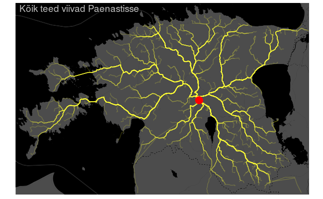

## Kuidas?

Alusandmetena kasutasin [Eesti kohanimeregistris](http://xgis.maaamet.ee/knravalik/) sisalduvad andmeid linnade, valdade, külade jne kohta. Andmetöötluseks ja visualiseerimiseks kasutasin R programmeerimiskeelt. Koodiga võib tutvuta siin: https://github.com/toomase/koik_teed_laulasmaale (esimeses versioonis leidsin teekonna Laulasmaale).